# Cálculo numérico y simulación

Alex Zambrano alexjzc@gmail.com

Introducción a R

# R como calculadora

A continuación encontraran algunas operaciones básicas en R

```r
5+8
2*4
75-12
(3-5)*4
sqrt(16) # raíz cuadrada de 16
exp(1) # número euler
log(3) # logaritmo natural de 3
log(1000,10) # logaritmo de 1000 en base 10
pi # número pi
sin(pi/2)
cos(pi)
tan(pi)
floor(4.8) # redondeo por debajo
ceiling(4.3) # redondeo por arriba
round(pi,digits=2) # redondear por 2 decimales
trunc(12.48) # redondeo eliminando decimales
```

# Actividad

Realice los siguientes cálculos aritméticos y redondee los resultados a 2 cifras decimales

- $\tfrac{\tfrac{24}{-8+7}}{9-6(2)}$
- $2^3(-7)+4-\left(\frac{1}{3}+\tfrac{1}{2}\right)$
- $\tfrac{\sqrt{16}+5(4)-3^{-2}}{3(4-8)+1}$
- $\frac{1}{2}\left[\left(\frac{5}{4}-2^{-1}\right)\frac{13}{4}-\sqrt{7}+8\div\left(2-\frac{1}{5}\right)-3^{2}\right]$
- $2\sin\left(\frac{\pi}{3}\right)+5\cos\left(\frac{\pi}{4}\right)-\frac{\tan\left(\frac{\pi}{6}\right)}{4}$
- $4\log_{2}(5)-3\log_3(7)+\frac{1}{3}\ln^3(8)$

# Cálculos sencillos

```r
x <- 3
x
```

```
## [1] 3
```

```r
x^3
```

```
## [1] 27
```

```r
x+5
```

```
## [1] 8
```

```r
x=3+7
x
```

```
## [1] 10
```

# Cálculos sencillos

```r
x^4
```

```
## [1] 10000
```

```r
x <- c(1, 4, 9, 2.25, 1/4)
x
```

```
## [1] 1.00 4.00 9.00 2.25 0.25
```

```r
length(x)
```

```
## [1] 5
```

```r
class(x)
```

```
## [1] "numeric"
```

```r
sqrt(x)
```

```
## [1] 1.0 2.0 3.0 1.5 0.5
```

# Operaciones sencillas con vectores

```r
x + 1
```

```
## [1]  2.00  5.00 10.00  3.25  1.25
```

```r
y <- 1:10
x + y
```

```
##  [1]  2.00  6.00 12.00  6.25  5.25  7.00 11.00 17.00 11.25 10.25
```

```r
x * y
```

```
##  [1]  1.00  8.00 27.00  9.00  1.25  6.00 28.00 72.00 20.25  2.50
```

```r
x^2
```

```
## [1]  1.0000 16.0000 81.0000  5.0625  0.0625
```

# Operaciones sencillas con vectores

```r
x^2 + y^3
```

```
##  [1]    2.0000   24.0000  108.0000   69.0625  125.0625  217.0000  359.0000
##  [8]  593.0000  734.0625 1000.0625
```

```r
exp(x)
```

```
## [1]    2.718282   54.598150 8103.083928    9.487736    1.284025
```

```r
log(x)
```

```
## [1]  0.0000000  1.3862944  2.1972246  0.8109302 -1.3862944
```

# ¿Y qué hago cuando necesito ayuda?

```r
help(exp)
help(log)
help(seq)
```

# Actividad

Considere los siguientes vectores $A^t=\begin{bmatrix} 3 & 9 & 8 & 7 \end{bmatrix}$ y $B^t=\begin{bmatrix} 1 & 5 & 0 & 4 \end{bmatrix}$ y $c=15$. Realice las siguientes operaciones

- $A^3$.
- $A+B$.
- $A\cdot B$.
- $c\cdot A$.
- $\log(A)$.
- $\exp(B\cdot A)$.

# Generar vectores con seq

```r
x1 <- seq(1, 100, by=2)
x1
```

```
##  [1]  1  3  5  7  9 11 13 15 17 19 21 23 25 27 29 31 33 35 37 39 41 43 45 47 49
## [26] 51 53 55 57 59 61 63 65 67 69 71 73 75 77 79 81 83 85 87 89 91 93 95 97 99
```

```r
seq(0, 100, 10)
```

```
##  [1]   0  10  20  30  40  50  60  70  80  90 100
```

```r
x <- seq(1, 100, length=10)
x
```

```
##  [1]   1  12  23  34  45  56  67  78  89 100
```

```r
length(x)
```

```
## [1] 10
```

```r
x <- seq(1, 100, length=10)
y <- seq(2, 100, length=50)
```

# Unir vectores con c

```r
z <- c(x, y)
z
```

```
##  [1]   1  12  23  34  45  56  67  78  89 100   2   4   6   8  10  12  14  16  18
## [20]  20  22  24  26  28  30  32  34  36  38  40  42  44  46  48  50  52  54  56
## [39]  58  60  62  64  66  68  70  72  74  76  78  80  82  84  86  88  90  92  94
## [58]  96  98 100
```

```r
z + c(1, 2)
```

```
##  [1]   2  14  24  36  46  58  68  80  90 102   3   6   7  10  11  14  15  18  19
## [20]  22  23  26  27  30  31  34  35  38  39  42  43  46  47  50  51  54  55  58
## [39]  59  62  63  66  67  70  71  74  75  78  79  82  83  86  87  90  91  94  95
## [58]  98  99 102
```

```r
z <- c(z, z, z, z)
z
```

```
##   [1]   1  12  23  34  45  56  67  78  89 100   2   4   6   8  10  12  14  16
##  [19]  18  20  22  24  26  28  30  32  34  36  38  40  42  44  46  48  50  52
##  [37]  54  56  58  60  62  64  66  68  70  72  74  76  78  80  82  84  86  88
##  [55]  90  92  94  96  98 100   1  12  23  34  45  56  67  78  89 100   2   4
##  [73]   6   8  10  12  14  16  18  20  22  24  26  28  30  32  34  36  38  40
##  [91]  42  44  46  48  50  52  54  56  58  60  62  64  66  68  70  72  74  76
## [109]  78  80  82  84  86  88  90  92  94  96  98 100   1  12  23  34  45  56
## [127]  67  78  89 100   2   4   6   8  10  12  14  16  18  20  22  24  26  28
## [145]  30  32  34  36  38  40  42  44  46  48  50  52  54  56  58  60  62  64
## [163]  66  68  70  72  74  76  78  80  82  84  86  88  90  92  94  96  98 100
## [181]   1  12  23  34  45  56  67  78  89 100   2   4   6   8  10  12  14  16
## [199]  18  20  22  24  26  28  30  32  34  36  38  40  42  44  46  48  50  52
## [217]  54  56  58  60  62  64  66  68  70  72  74  76  78  80  82  84  86  88
## [235]  90  92  94  96  98 100
```

# Generar vectores con rep

```r
rep(1:10, 4)
```

```
##  [1]  1  2  3  4  5  6  7  8  9 10  1  2  3  4  5  6  7  8  9 10  1  2  3  4  5
## [26]  6  7  8  9 10  1  2  3  4  5  6  7  8  9 10
```

```r
length(z)
```

```
## [1] 240
```

```r
rep(c(1, 2, 3), 10)
```

```
##  [1] 1 2 3 1 2 3 1 2 3 1 2 3 1 2 3 1 2 3 1 2 3 1 2 3 1 2 3 1 2 3
```

```r
rep(c(1, 2, 3), each=10)
```

```
##  [1] 1 1 1 1 1 1 1 1 1 1 2 2 2 2 2 2 2 2 2 2 3 3 3 3 3 3 3 3 3 3
```

# Indexado numérico de vectores

```r
x <- seq(1, 100, 2)
x
```

```
##  [1]  1  3  5  7  9 11 13 15 17 19 21 23 25 27 29 31 33 35 37 39 41 43 45 47 49
## [26] 51 53 55 57 59 61 63 65 67 69 71 73 75 77 79 81 83 85 87 89 91 93 95 97 99
```

```r
x[c(1, 2, 3, 4, 5)]
```

```
## [1] 1 3 5 7 9
```

```r
x[1:5]
```

```
## [1] 1 3 5 7 9
```

```r
x[10:5]
```

```
## [1] 19 17 15 13 11  9
```

# Indexado de vectores con condiciones lógicas

```r
condicion <- (x>30)
condicion
```

```
##  [1] FALSE FALSE FALSE FALSE FALSE FALSE FALSE FALSE FALSE FALSE FALSE FALSE
## [13] FALSE FALSE FALSE  TRUE  TRUE  TRUE  TRUE  TRUE  TRUE  TRUE  TRUE  TRUE
## [25]  TRUE  TRUE  TRUE  TRUE  TRUE  TRUE  TRUE  TRUE  TRUE  TRUE  TRUE  TRUE
## [37]  TRUE  TRUE  TRUE  TRUE  TRUE  TRUE  TRUE  TRUE  TRUE  TRUE  TRUE  TRUE
## [49]  TRUE  TRUE
```

```r
class(condicion)
```

```
## [1] "logical"
```

```r
x==37
```

```
##  [1] FALSE FALSE FALSE FALSE FALSE FALSE FALSE FALSE FALSE FALSE FALSE FALSE
## [13] FALSE FALSE FALSE FALSE FALSE FALSE  TRUE FALSE FALSE FALSE FALSE FALSE
## [25] FALSE FALSE FALSE FALSE FALSE FALSE FALSE FALSE FALSE FALSE FALSE FALSE
## [37] FALSE FALSE FALSE FALSE FALSE FALSE FALSE FALSE FALSE FALSE FALSE FALSE
## [49] FALSE FALSE
```

```r
x[x==37]
```

```
## [1] 37
```

```r
x[x!=9]
```

```
##  [1]  1  3  5  7 11 13 15 17 19 21 23 25 27 29 31 33 35 37 39 41 43 45 47 49 51
## [26] 53 55 57 59 61 63 65 67 69 71 73 75 77 79 81 83 85 87 89 91 93 95 97 99
```

```r
x[x>20]
```

```
##  [1] 21 23 25 27 29 31 33 35 37 39 41 43 45 47 49 51 53 55 57 59 61 63 65 67 69
## [26] 71 73 75 77 79 81 83 85 87 89 91 93 95 97 99
```

# Indexado de vectores con %in%

```r
y <- seq(101, 200, 2)
y %in% c(101, 127, 141)
```

```
##  [1]  TRUE FALSE FALSE FALSE FALSE FALSE FALSE FALSE FALSE FALSE FALSE FALSE
## [13] FALSE  TRUE FALSE FALSE FALSE FALSE FALSE FALSE  TRUE FALSE FALSE FALSE
## [25] FALSE FALSE FALSE FALSE FALSE FALSE FALSE FALSE FALSE FALSE FALSE FALSE
## [37] FALSE FALSE FALSE FALSE FALSE FALSE FALSE FALSE FALSE FALSE FALSE FALSE
## [49] FALSE FALSE
```

```r
y
```

```
##  [1] 101 103 105 107 109 111 113 115 117 119 121 123 125 127 129 131 133 135 137
## [20] 139 141 143 145 147 149 151 153 155 157 159 161 163 165 167 169 171 173 175
## [39] 177 179 181 183 185 187 189 191 193 195 197 199
```

```r
y[y %in% c(101, 127, 141)]
```

```
## [1] 101 127 141
```

# Indexado de vectores con condiciones múltiples

```r
z <- c(x, y)
z
```

```
##   [1]   1   3   5   7   9  11  13  15  17  19  21  23  25  27  29  31  33  35
##  [19]  37  39  41  43  45  47  49  51  53  55  57  59  61  63  65  67  69  71
##  [37]  73  75  77  79  81  83  85  87  89  91  93  95  97  99 101 103 105 107
##  [55] 109 111 113 115 117 119 121 123 125 127 129 131 133 135 137 139 141 143
##  [73] 145 147 149 151 153 155 157 159 161 163 165 167 169 171 173 175 177 179
##  [91] 181 183 185 187 189 191 193 195 197 199
```

```r
z>150
```

```
##   [1] FALSE FALSE FALSE FALSE FALSE FALSE FALSE FALSE FALSE FALSE FALSE FALSE
##  [13] FALSE FALSE FALSE FALSE FALSE FALSE FALSE FALSE FALSE FALSE FALSE FALSE
##  [25] FALSE FALSE FALSE FALSE FALSE FALSE FALSE FALSE FALSE FALSE FALSE FALSE
##  [37] FALSE FALSE FALSE FALSE FALSE FALSE FALSE FALSE FALSE FALSE FALSE FALSE
##  [49] FALSE FALSE FALSE FALSE FALSE FALSE FALSE FALSE FALSE FALSE FALSE FALSE
##  [61] FALSE FALSE FALSE FALSE FALSE FALSE FALSE FALSE FALSE FALSE FALSE FALSE
##  [73] FALSE FALSE FALSE  TRUE  TRUE  TRUE  TRUE  TRUE  TRUE  TRUE  TRUE  TRUE
##  [85]  TRUE  TRUE  TRUE  TRUE  TRUE  TRUE  TRUE  TRUE  TRUE  TRUE  TRUE  TRUE
##  [97]  TRUE  TRUE  TRUE  TRUE
```

```r
z[z>150]
```

```
##  [1] 151 153 155 157 159 161 163 165 167 169 171 173 175 177 179 181 183 185 187
## [20] 189 191 193 195 197 199
```

```r
z[z<30 | z>150]
```

```
##  [1]   1   3   5   7   9  11  13  15  17  19  21  23  25  27  29 151 153 155 157
## [20] 159 161 163 165 167 169 171 173 175 177 179 181 183 185 187 189 191 193 195
## [39] 197 199
```

```r
z[z>=30 & z<=150]
```

```
##  [1]  31  33  35  37  39  41  43  45  47  49  51  53  55  57  59  61  63  65  67
## [20]  69  71  73  75  77  79  81  83  85  87  89  91  93  95  97  99 101 103 105
## [39] 107 109 111 113 115 117 119 121 123 125 127 129 131 133 135 137 139 141 143
## [58] 145 147 149
```

```r
z[c(1, 10, 40, 80)]
```

```
## [1]   1  19  79 159
```

# Indexado de vectores con condiciones múltiples

```r
cond  <-  (x>10) & (x<50)
cond
```

```
##  [1] FALSE FALSE FALSE FALSE FALSE  TRUE  TRUE  TRUE  TRUE  TRUE  TRUE  TRUE
## [13]  TRUE  TRUE  TRUE  TRUE  TRUE  TRUE  TRUE  TRUE  TRUE  TRUE  TRUE  TRUE
## [25]  TRUE FALSE FALSE FALSE FALSE FALSE FALSE FALSE FALSE FALSE FALSE FALSE
## [37] FALSE FALSE FALSE FALSE FALSE FALSE FALSE FALSE FALSE FALSE FALSE FALSE
## [49] FALSE FALSE
```

```r
x[cond]
```

```
##  [1] 11 13 15 17 19 21 23 25 27 29 31 33 35 37 39 41 43 45 47 49
```

# Con las condiciones se pueden hacer operaciones

```r
sum(cond)
```

```
## [1] 20
```

```r
!cond
```

```
##  [1]  TRUE  TRUE  TRUE  TRUE  TRUE FALSE FALSE FALSE FALSE FALSE FALSE FALSE
## [13] FALSE FALSE FALSE FALSE FALSE FALSE FALSE FALSE FALSE FALSE FALSE FALSE
## [25] FALSE  TRUE  TRUE  TRUE  TRUE  TRUE  TRUE  TRUE  TRUE  TRUE  TRUE  TRUE
## [37]  TRUE  TRUE  TRUE  TRUE  TRUE  TRUE  TRUE  TRUE  TRUE  TRUE  TRUE  TRUE
## [49]  TRUE  TRUE
```

```r
sum(!cond)
```

```
## [1] 30
```

```r
length(x[cond])
```

```
## [1] 20
```

```r
length(x[!cond])
```

```
## [1] 30
```

```r
as.numeric(cond)
```

```
##  [1] 0 0 0 0 0 1 1 1 1 1 1 1 1 1 1 1 1 1 1 1 1 1 1 1 1 0 0 0 0 0 0 0 0 0 0 0 0 0
## [39] 0 0 0 0 0 0 0 0 0 0 0 0
```

# Funciones predefinidas

```r
summary(x)
```

```
##    Min. 1st Qu.  Median    Mean 3rd Qu.    Max.
##     1.0    25.5    50.0    50.0    74.5    99.0
```

```r
mean(x)
```

```
## [1] 50
```

```r
sd(x)
```

```
## [1] 29.15476
```

```r
median(x)
```

```
## [1] 50
```

```r
max(x)
```

```
## [1] 99
```

```r
min(x)
```

```
## [1] 1
```

```r
range(x)
```

```
## [1]  1 99
```

```r
quantile(x)
```

```
##   0%  25%  50%  75% 100%
##  1.0 25.5 50.0 74.5 99.0
```

# Actividad

Considere la construcción de los siguientes vectores

- Considere un vector $A$ cuya secuencia sea de 10 a 1000 y que vaya de 20 en 20.
- Determine la longitud de este vector.
- Construya un vector $B$ cuya secuencia se desde 1 hasta la longitud del vector $A$.
- $A+B$.
- Construya un vector $C$ cuya secuencia sea desde 1 hasta 20.
- Construya un vector $D$ cuya secuencia sea los 20 primeros números de $A$.
- Construya el vector $[C\,D]$.

# Construcción de matrices

```r
z <- 1:12
M  <-  matrix(z, nrow=3)
M
```

```
##      [,1] [,2] [,3] [,4]
## [1,]    1    4    7   10
## [2,]    2    5    8   11
## [3,]    3    6    9   12
```

```r
z
```

```
##  [1]  1  2  3  4  5  6  7  8  9 10 11 12
```

```r
class(M)
```

```
## [1] "matrix" "array"
```

```r
dim(M)
```

```
## [1] 3 4
```

```r
summary(M)
```

```
##        V1            V2            V3            V4
##  Min.   :1.0   Min.   :4.0   Min.   :7.0   Min.   :10.0
##  1st Qu.:1.5   1st Qu.:4.5   1st Qu.:7.5   1st Qu.:10.5
##  Median :2.0   Median :5.0   Median :8.0   Median :11.0
##  Mean   :2.0   Mean   :5.0   Mean   :8.0   Mean   :11.0
##  3rd Qu.:2.5   3rd Qu.:5.5   3rd Qu.:8.5   3rd Qu.:11.5
##  Max.   :3.0   Max.   :6.0   Max.   :9.0   Max.   :12.0
```

# Matrices a partir de vectores: rbind y cbind

```r
x <- 1:10
y <- 1:10
z <- 1:10
z <- y <- x <- 1:10

M <- cbind(x, y, z)
M
```

```
##        x  y  z
##  [1,]  1  1  1
##  [2,]  2  2  2
##  [3,]  3  3  3
##  [4,]  4  4  4
##  [5,]  5  5  5
##  [6,]  6  6  6
##  [7,]  7  7  7
##  [8,]  8  8  8
##  [9,]  9  9  9
## [10,] 10 10 10
```

```r
M <- rbind(x, y, z)
M
```

```
##   [,1] [,2] [,3] [,4] [,5] [,6] [,7] [,8] [,9] [,10]
## x    1    2    3    4    5    6    7    8    9    10
## y    1    2    3    4    5    6    7    8    9    10
## z    1    2    3    4    5    6    7    8    9    10
```

```r
rbind(M, M)
```

```
##   [,1] [,2] [,3] [,4] [,5] [,6] [,7] [,8] [,9] [,10]
## x    1    2    3    4    5    6    7    8    9    10
## y    1    2    3    4    5    6    7    8    9    10
## z    1    2    3    4    5    6    7    8    9    10
## x    1    2    3    4    5    6    7    8    9    10
## y    1    2    3    4    5    6    7    8    9    10
## z    1    2    3    4    5    6    7    8    9    10
```

```r
cbind(M, M)
```

```
##   [,1] [,2] [,3] [,4] [,5] [,6] [,7] [,8] [,9] [,10] [,11] [,12] [,13] [,14]
## x    1    2    3    4    5    6    7    8    9    10     1     2     3     4
## y    1    2    3    4    5    6    7    8    9    10     1     2     3     4
## z    1    2    3    4    5    6    7    8    9    10     1     2     3     4
##   [,15] [,16] [,17] [,18] [,19] [,20]
## x     5     6     7     8     9    10
## y     5     6     7     8     9    10
## z     5     6     7     8     9    10
```

# Transponer una matriz

```r
t(M)
```

```
##        x  y  z
##  [1,]  1  1  1
##  [2,]  2  2  2
##  [3,]  3  3  3
##  [4,]  4  4  4
##  [5,]  5  5  5
##  [6,]  6  6  6
##  [7,]  7  7  7
##  [8,]  8  8  8
##  [9,]  9  9  9
## [10,] 10 10 10
```

```r
class(t)
```

```
## [1] "function"
```

```r
dim(t(M))
```

```
## [1] 10  3
```

# Operaciones con matrices

```r
M * M
```

```
##   [,1] [,2] [,3] [,4] [,5] [,6] [,7] [,8] [,9] [,10]
## x    1    4    9   16   25   36   49   64   81   100
## y    1    4    9   16   25   36   49   64   81   100
## z    1    4    9   16   25   36   49   64   81   100
```

```r
M ^ 2
```

```
##   [,1] [,2] [,3] [,4] [,5] [,6] [,7] [,8] [,9] [,10]
## x    1    4    9   16   25   36   49   64   81   100
## y    1    4    9   16   25   36   49   64   81   100
## z    1    4    9   16   25   36   49   64   81   100
```

```r
M %*% t(M)
```

```
##     x   y   z
## x 385 385 385
## y 385 385 385
## z 385 385 385
```

# Operaciones con matrices: funciones predefinidas

```r
sum(M)
```

```
## [1] 165
```

```r
rowSums(M)
```

```
##  x  y  z
## 55 55 55
```

```r
colSums(M)
```

```
##  [1]  3  6  9 12 15 18 21 24 27 30
```

```r
rowMeans(M)
```

```
##   x   y   z
## 5.5 5.5 5.5
```

```r
colMeans(M)
```

```
##  [1]  1  2  3  4  5  6  7  8  9 10
```

# La función apply

```r
apply(M, 1, sum)
```

```
##  x  y  z
## 55 55 55
```

```r
apply(M, 2, sum)
```

```
##  [1]  3  6  9 12 15 18 21 24 27 30
```

```r
apply(M, 1, mean)
```

```
##   x   y   z
## 5.5 5.5 5.5
```

```r
apply(M, 2, mean)
```

```
##  [1]  1  2  3  4  5  6  7  8  9 10
```

```r
apply(M, 1, sd, na.rm=TRUE)
```

```
##       x       y       z
## 3.02765 3.02765 3.02765
```

```r
apply(M, 2, sd)
```

```
##  [1] 0 0 0 0 0 0 0 0 0 0
```

# Indexado de matrices

```r
M
```

```
##   [,1] [,2] [,3] [,4] [,5] [,6] [,7] [,8] [,9] [,10]
## x    1    2    3    4    5    6    7    8    9    10
## y    1    2    3    4    5    6    7    8    9    10
## z    1    2    3    4    5    6    7    8    9    10
```

```r
M[1, ]
```

```
##  [1]  1  2  3  4  5  6  7  8  9 10
```

```r
M[, 1]
```

```
## x y z
## 1 1 1
```

```r
sum(M[, 1])
```

```
## [1] 3
```

```r
M[1:2, ]
```

```
##   [,1] [,2] [,3] [,4] [,5] [,6] [,7] [,8] [,9] [,10]
## x    1    2    3    4    5    6    7    8    9    10
## y    1    2    3    4    5    6    7    8    9    10
```

```r
M[1:2, 2:3]
```

```
##   [,1] [,2]
## x    2    3
## y    2    3
```

```r
M[1, c(1, 4)]
```

```
## [1] 1 4
```

```r
M[-1,]
```

```
##   [,1] [,2] [,3] [,4] [,5] [,6] [,7] [,8] [,9] [,10]
## y    1    2    3    4    5    6    7    8    9    10
## z    1    2    3    4    5    6    7    8    9    10
```

```r
M[-c(1, 2),]
```

```
##  [1]  1  2  3  4  5  6  7  8  9 10
```

# Actividad

Considere la siguiente matriz
$$A=\begin{bmatrix}
1 & 3 & 5\\
7 & 9 & 11
\end{bmatrix}$$
Realice las siguientes actividades

- Cambie el elemento $A(2,3)$ por cero.
- Construya una matriz $B$ la cual sea la transpuesta de $A$.
- Construya una matriz $C$ la cual este formada por la matriz $B$ y sea aumenta con una idéntica de orden 3.
- $A\cdot B$.
- Sume las filas y columnas de la C.
- Calcule el promedio por filas y columnas C.
- Elimine la columnas impares de la matriz C.

# Valores perdidos

¿Qué es NA?

```r
class(NA)
```

```
## [1] "logical"
```

```r
x <- rnorm(100)
idx <- sample(length(x), 10)
idx
```

```
##  [1] 39 92 85 45 55  2 66 11 13 84
```

```r
x[idx]
```

```
##  [1] -2.3252642 -2.1579731  1.9566958  0.1888464 -0.1079123 -0.2694653
##  [7] -1.2584235 -1.3076356  0.6165313 -0.3916994
```

```r
x2 <- x
x2[idx] <- NA
x2
```

```
##   [1]  0.82745882          NA -0.47101899  0.10389181 -0.18748208  0.53723437
##   [7]  1.56120804  1.72981452  0.28151814 -0.71921576          NA -0.41753593
##  [13]          NA -0.57257507  2.01191837  1.27099483 -0.24079933  0.52232170
##  [19]  0.92025090  1.94780712  0.42693130 -0.98204694 -0.32817834  1.24944857
##  [25] -0.61241365  1.57840310  0.60361501  2.13180748 -0.71860094  1.79556049
##  [31]  0.64566333 -0.15564895 -0.44782078 -1.34909202  0.67874940  0.46852945
##  [37]  0.81997284 -0.24695665          NA -0.23074464 -0.13643072  0.93170025
##  [43] -1.31135362 -0.14576957          NA -0.81830109  1.31170955 -0.73788401
##  [49] -0.15345438  0.49079604  0.47673992  0.28224193 -0.42389236 -0.07910368
##  [55]          NA  0.61447833 -1.63095971  0.21897066 -0.42485654 -1.27969971
##  [61] -0.72424704 -3.11731021 -1.10631236  1.37376758  1.46066229          NA
##  [67] -0.99905134 -1.56132370 -0.09907597 -0.22403180 -0.47294901 -1.40795764
##  [73] -2.39902432 -0.07654556  2.72119267 -0.41634215 -0.53730996 -0.77488413
##  [79] -0.98143867  1.11074557  0.63537774  0.91521203 -0.51207902          NA
##  [85]          NA  0.15090541 -0.64258031  1.73975962 -0.19967589  0.32974836
##  [91]  1.29269153          NA  0.15405142  1.44728015  0.83322677 -0.95454958
##  [97]  0.21034364 -0.60764198  0.78724508 -0.71008283
```

# NA en las funciones

```r
summary(x)
```

```
##     Min.  1st Qu.   Median     Mean  3rd Qu.     Max.
## -3.11731 -0.61996 -0.12217  0.03199  0.70587  2.72119
```

```r
mean(x)
```

```
## [1] 0.03199397
```

```r
sum(x)
```

```
## [1] 3.199397
```

```r
summary(x2)
```

```
##     Min.  1st Qu.   Median     Mean  3rd Qu.     Max.     NA's
## -3.11731 -0.59888 -0.08909  0.09173  0.81179  2.72119       10
```

```r
mean(x2)
```

```
## [1] NA
```

```r
sum(x2)
```

```
## [1] NA
```

```r
mean(x2, na.rm=TRUE)
```

```
## [1] 0.09172997
```

```r
sum(x2, na.rm=TRUE)
```

```
## [1] 8.255697
```

```r
sd(x2, na.rm=TRUE)
```

```
## [1] 1.042853
```

```r
class(TRUE)
```

```
## [1] "logical"
```

# Actividad

Considere una matriz $A$ de números aleatorios (runif) la cual tenga 10 filas y 5 columnas.

Realice las siguientes actividades

- Asigne como valores perdidos los siguientes elementos $A(2,3), A(4,5), A(3,4), A(2,2), A(8,1), A(9,1)$.
- Calcule la media de cada columna.
- Calcule la desviación de cada fila.

# Actividad

Del libro http://www.math.csi.cuny.edu/Statistics/R/simpleR/printable/simpleR.pdf, realizar los ejercicios capitulo 2.

# Definición de funciones

Para definir una función usamos la función function

Forma general

```r
NombreDeFuncion <-function(arg 1, arg 2, ...) expresión
```

Ejemplo

```r
myFun <- function(x, y=c(5,6,7)) x + y
myFun(4)
```

```
## [1]  9 10 11
```

```r
class(myFun)
```

```
## [1] "function"
```

# Definición de funciones

Ejemplo se desea escribir una función que realice lo siguiente
$$f(x,y)=x^2+y^2$$

```r
circulo <- function(x,y){
  x^2 + y^2
}
circulo(3,4)
```

```
## [1] 25
```

# Definir una función a partir de funciones

```r
foo  <-  function(x, ...){
  mx <- mean(x, ...)
  medx <- median(x, ...)
  sdx <- sd(x, ...)
  c(mx, medx, sdx)
  }
```

O en forma resumida:

```r
foo <- function(x, ...){c(mean(x, ...), median(x, ...), sd(x, ...))}
```

# Uso de funciones

```r
foo(1:10)
```

```
## [1] 5.50000 5.50000 3.02765
```

```r
rnorm(100)
```

```
##   [1] -0.09248011  0.24317383 -0.34526878 -0.17769109  1.18823452 -0.58940553
##   [7]  0.05767038 -0.49793561 -1.42788274  1.30921830  0.91089774  0.55559612
##  [13] -1.04222147 -0.91455099  0.73398114 -0.43168217 -0.20265411 -0.03633449
##  [19] -0.11484681 -0.69162470  0.35101550 -0.50500044 -0.41904312  0.64383682
##  [25]  0.06896445  0.23898958 -1.27073850 -0.12528199  0.04824804  1.96553490
##  [31]  0.19294951  0.08231688  2.05048101 -0.12655854 -1.14344446 -0.18714854
##  [37] -1.70627487  1.52600577 -0.30372307  1.42861827  0.49851064 -1.33557761
##  [43]  0.68786711 -0.76225097 -1.32088249  0.95814660  1.28574553 -0.74812779
##  [49]  1.08214467 -0.38962813  0.35885478 -0.10042380  0.06296140  0.32236230
##  [55] -0.19671013 -0.01779847  0.59571154 -1.51198917  0.17714297 -1.58230848
##  [61]  0.20434019 -1.64561639 -0.72898533 -0.80105686 -0.60100594 -1.86231337
##  [67]  0.54911322 -0.87227739 -0.94060937 -0.70948777 -0.75530281 -0.47703073
##  [73]  1.02002402  1.05330695 -1.90757072 -0.23535352  1.19065844 -0.64674371
##  [79]  0.86276086  0.17673540  1.22758822 -1.54410263 -0.13500204  0.89898617
##  [85]  0.53966615 -0.42450689 -0.03477308 -0.52645378  1.18308091 -0.12692539
##  [91]  1.34953175  0.91368722  0.45550539  1.19858833 -0.92452001  0.34195806
##  [97]  0.27269049  0.34391497 -1.34791277 -0.58983828
```

```r
foo(rnorm(1e5))
```

```
## [1] 0.003917947 0.003936290 0.997933967
```

# Actividades

# Operadores de control de flujo

```r
if(cond) expr
if(cond) cons.expr  else  alt.expr

for(var in seq) expr
while(cond) expr
repeat expr
break
next
```

# Ejemplo

De un vector de valores aleatorios normales, elevar al cuadrado cada uno de ellos.

```r
for(n in c(2,5,10,20,50)) {
x <- rnorm(n)
cat(n,":", sum(x^2),"\n")
}
```

```
## 2 : 4.872803
## 5 : 4.195574
## 10 : 24.96751
## 20 : 25.72579
## 50 : 62.15959
```

# Ejemplo

Del listado de números del-5 a 5, elevar a la tres cada término.

```r
for(i in -5:5)
{cat(i,"\t", i^3,"\n")
}
```

```
## -5    -125
## -4    -64
## -3    -27
## -2    -8
## -1    -1
## 0     0
## 1     1
## 2     8
## 3     27
## 4     64
## 5     125
```

# Ejemplo

De un vector de valores aleatorios normales asignarles 1 aquellos valores mayores que 0.

```r
set.seed(12082015)
x <- rnorm(10)
x2 <- as.numeric(x>0)
for (i in 1:length(x2)){
if (x[i]<0) x2[i] <- 0 else x2[i] <- 1
}
cbind(x, x2)
```

```
##                 x x2
##  [1,]  0.05583942  1
##  [2,] -1.03448585  0
##  [3,] -0.23856100  0
##  [4,]  0.73465696  1
##  [5,]  0.12637545  1
##  [6,] -0.70524819  0
##  [7,]  0.09321508  1
##  [8,]  0.70260777  1
##  [9,]  0.33520915  1
## [10,]  1.45958329  1
```

Otra forma

```r
set.seed(12082015)
x <- rnorm(10)
ifelse(x>0, 1, 0)
```

```
##  [1] 1 0 0 1 1 0 1 1 1 1
```

# Ejemplo

Empezando con $i = 4$ elevar al cuadrado cada valor hasta que $i\leq 10$

```r
i<-4
while(i<=10){
  print(i^2);i=i+1
}
```

```
## [1] 16
## [1] 25
## [1] 36
## [1] 49
## [1] 64
## [1] 81
## [1] 100
```

Otra forma

```r
i<-4
repeat{ print(i^2)
  i=i+1
  if(i > 10) break
}
```

```
## [1] 16
## [1] 25
## [1] 36
## [1] 49
## [1] 64
## [1] 81
## [1] 100
```

# Operadores lógicos

```r
! x
x & y
x && y
x | y
x || y
xor(x, y)
```

# Operadores de sintaxis

```r
:: :::   #access variables in a namespace
$ @  #component / slot extraction
[ [[     #indexing
^    #exponentiation (right to left)
- +  #unary minus and plus
:    #sequence operator
%any%    #special operators (including %% and %/%)
* /  #multiply, divide
+ -  #(binary) add, subtract
< > <= >= == !=  #ordering and comparison
!    #negation
& &&     #and
| ||     #or
~    #as in formulae
-> ->>   #rightwards assignment
<- <<-   #assignment (right to left)
=    #assignment (right to left)
?    #help (unary and binary)
```

# Ejemplo

Creamos una función que calcule el logaritmo de un número

```r
logaritmo<-function(x){
  if(is.numeric(x)&& min(x)!=0){
    log(x)
  }
  else{
    stop("x no es numérico o es cero")
  }
}

logaritmo(3)
```

```
## [1] 1.098612
```

```r
logaritmo(10)
```

```
## [1] 2.302585
```

```r
logaritmo(exp(1))
```

```
## [1] 1
```

# Ejemplo

Creamos una función que calcule el inverso de un número

```r
Inverso<-function(x) ifelse(x==0,NA,1/x)

Inverso(-2:3)
```

```
## [1] -0.5000000 -1.0000000         NA  1.0000000  0.5000000  0.3333333
```

```r
Inverso(-10:10)
```

```
##  [1] -0.1000000 -0.1111111 -0.1250000 -0.1428571 -0.1666667 -0.2000000
##  [7] -0.2500000 -0.3333333 -0.5000000 -1.0000000         NA  1.0000000
## [13]  0.5000000  0.3333333  0.2500000  0.2000000  0.1666667  0.1428571
## [19]  0.1250000  0.1111111  0.1000000
```

# Ejemplo

Factorial de un número

```r
factorial<-function(n){
  f<-1
  if(n>1){
    for(i in 1:n){
      f<-f*i
    }
  }
  return(f)
}

factorial(3)
```

```
## [1] 6
```

```r
factorial(25)
```

```
## [1] 1.551121e+25
```

```r
factorial(0)
```

```
## [1] 1
```

# Ejemplo

Progresión aritmética
$$a_n=a_1+(n-1)d$$

```r
#Formula explícita
arit.1<-function(n=1,a1=1,d=1){
  a1+d*(n-1)
}

#Formula recursiva
arit.2<-function(n=1,a1=1,d=1){
  a<-numeric(n)
  a[1]<-a1
  if(n>1){
    for(i in 2:n){
      a[i]=a[i-1]+d
    }
  }
  return(a[n])
}

#Formula vectorial
arit.3<-function(n=1,a1=1,d=1){
  A1<-rep(a1,n)
  D<-rep(d,n)
  N<-0:(n-1)
  A<-A1+N*D
  return(A[n])
}

arit.1(n=5,a1=2,d=2)
```

```
## [1] 10
```

```r
arit.2(n=5,a1=2,d=2)
```

```
## [1] 10
```

```r
arit.3(n=5,a1=2,d=2)
```

```
## [1] 10
```

##Actividad Realice las siguientes actividades

- Considere un ciclo cuya ejecución permita encontrar el mayor número factorial no excede a $10^{100}$.
- Construya una función que devuelva la información si el número es negativo, par o impar.
- Construya una función que permita realizar la Progresión geométrica $a_n=a_1r^{n-1}$ donde $a_1$ primer término y $r$ razón.
- Para los siguientes valores (x, y): (-2,-1), (-2,0), (-2,1), (1,2), (1,-2), (3,2). Evalue lo sguiente
  $$f(x,y)=\begin{cases}
  x + y & \text{ si } x>0 \text{ ó } y>0\\
  x - y & \text{ si } x>0 \text{ ó } y<0\\
  0 & \text{ en otro caso.}
  \end{cases}$$
- Crear una susesión de números de Fibonacci menores a 5000.

##Gráficos

```r
summary(mtcars)
```

```
##       mpg             cyl             disp             hp
##  Min.   :10.40   Min.   :4.000   Min.   : 71.1   Min.   : 52.0
##  1st Qu.:15.43   1st Qu.:4.000   1st Qu.:120.8   1st Qu.: 96.5
##  Median :19.20   Median :6.000   Median :196.3   Median :123.0
##  Mean   :20.09   Mean   :6.188   Mean   :230.7   Mean   :146.7
##  3rd Qu.:22.80   3rd Qu.:8.000   3rd Qu.:326.0   3rd Qu.:180.0
##  Max.   :33.90   Max.   :8.000   Max.   :472.0   Max.   :335.0
##       drat             wt             qsec             vs
##  Min.   :2.760   Min.   :1.513   Min.   :14.50   Min.   :0.0000
##  1st Qu.:3.080   1st Qu.:2.581   1st Qu.:16.89   1st Qu.:0.0000
##  Median :3.695   Median :3.325   Median :17.71   Median :0.0000
##  Mean   :3.597   Mean   :3.217   Mean   :17.85   Mean   :0.4375
##  3rd Qu.:3.920   3rd Qu.:3.610   3rd Qu.:18.90   3rd Qu.:1.0000
##  Max.   :4.930   Max.   :5.424   Max.   :22.90   Max.   :1.0000
##        am              gear            carb
##  Min.   :0.0000   Min.   :3.000   Min.   :1.000
##  1st Qu.:0.0000   1st Qu.:3.000   1st Qu.:2.000
##  Median :0.0000   Median :4.000   Median :2.000
##  Mean   :0.4062   Mean   :3.688   Mean   :2.812
##  3rd Qu.:1.0000   3rd Qu.:4.000   3rd Qu.:4.000
##  Max.   :1.0000   Max.   :5.000   Max.   :8.000
```

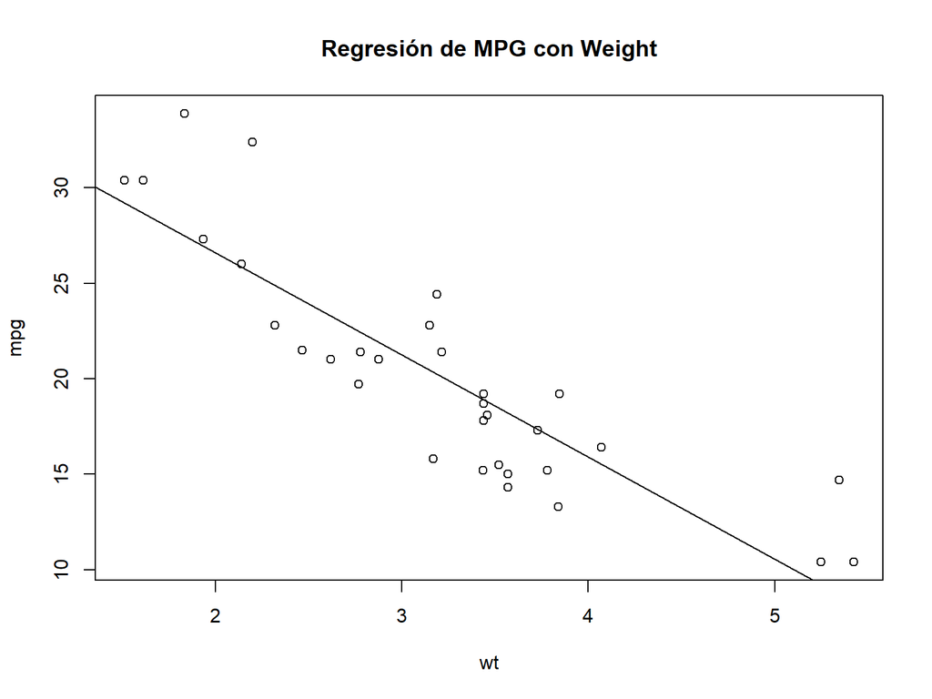

```r
attach(mtcars)
plot(wt, mpg)
abline(lm(mpg~wt))
title("Regresión de MPG con Weight")
```

##Histograma

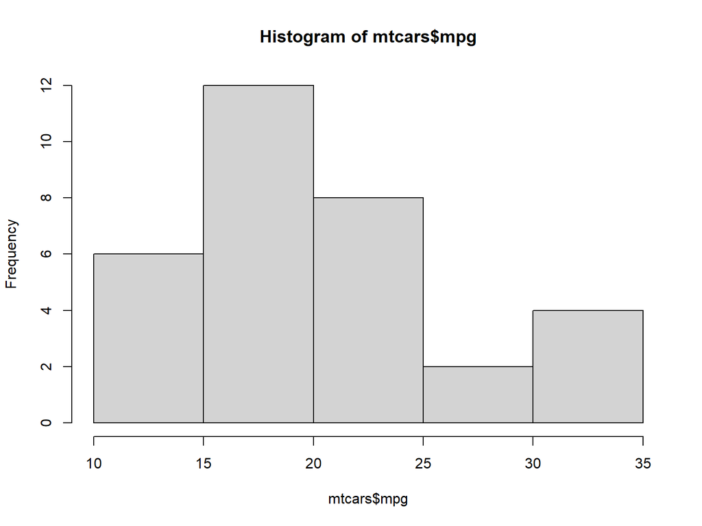

```r
hist(mtcars$mpg)
```

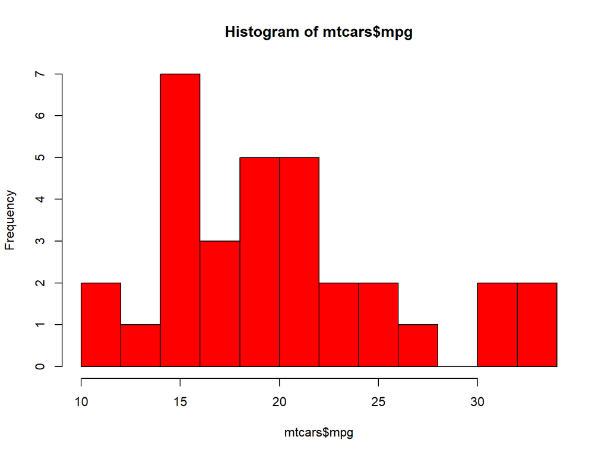

```r
#Histograma con barras rojas
hist(mtcars$mpg, breaks=12, col="red")
```

##Gráfico de densidad

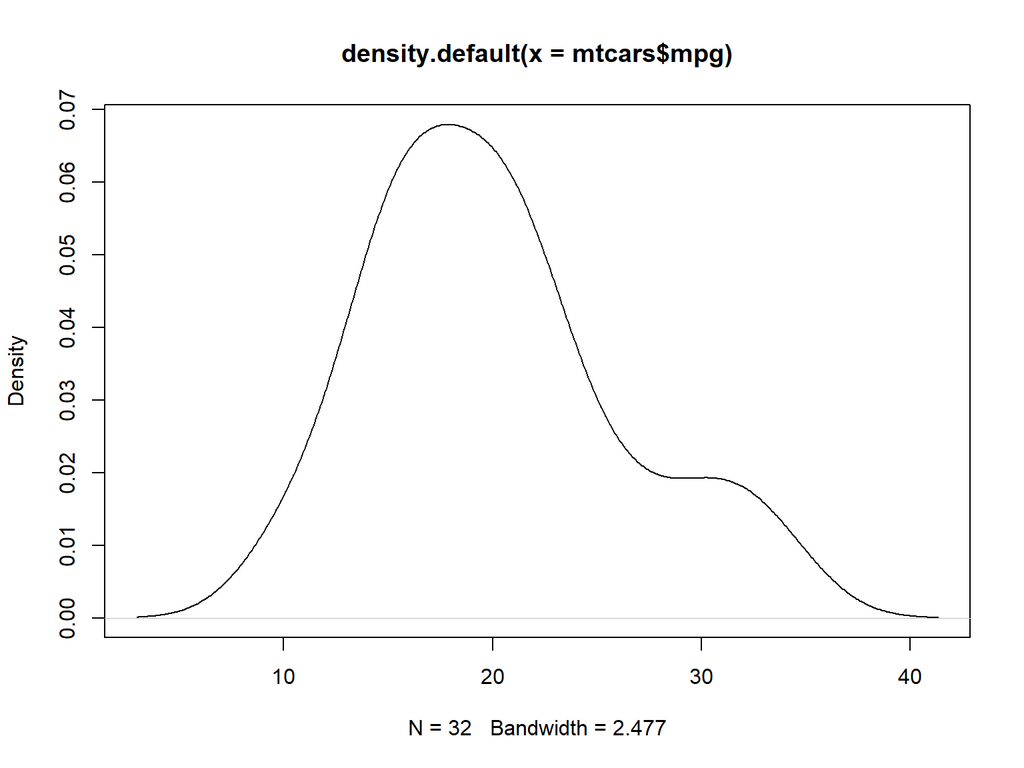

```r
d <- density(mtcars$mpg)
plot(d)
```

##Diagrama de puntos

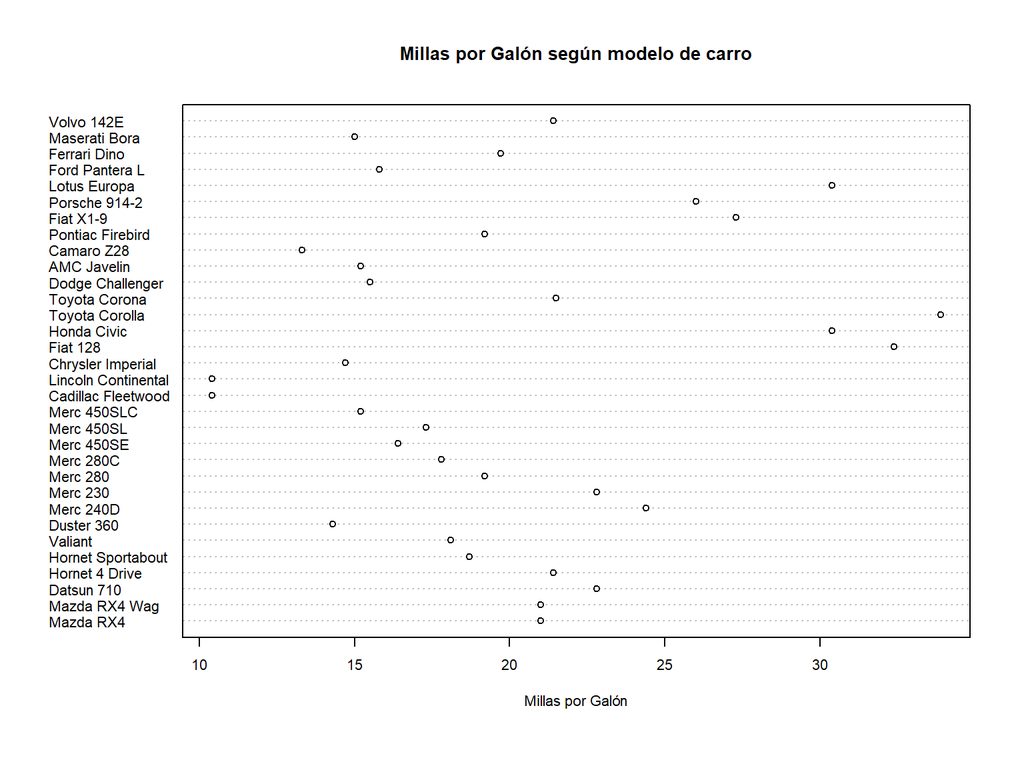

```r
dotchart(mtcars$mpg,labels=row.names(mtcars),cex=.7, main="Millas por Galón según modelo de carro",
         xlab="Millas por Galón")
```

##Gráfico de Barras

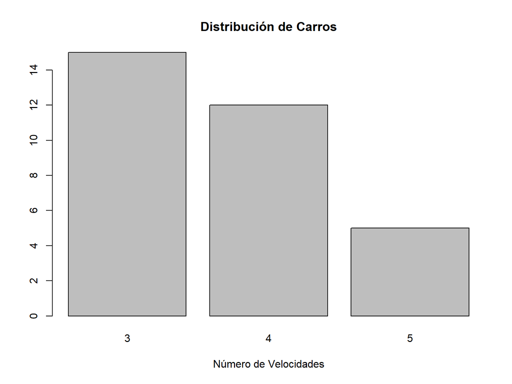

```r
conteos <- table(mtcars$gear)
barplot(conteos, main="Distribución de Carros", xlab="Número de Velocidades")
```

##Gráfico de Barras

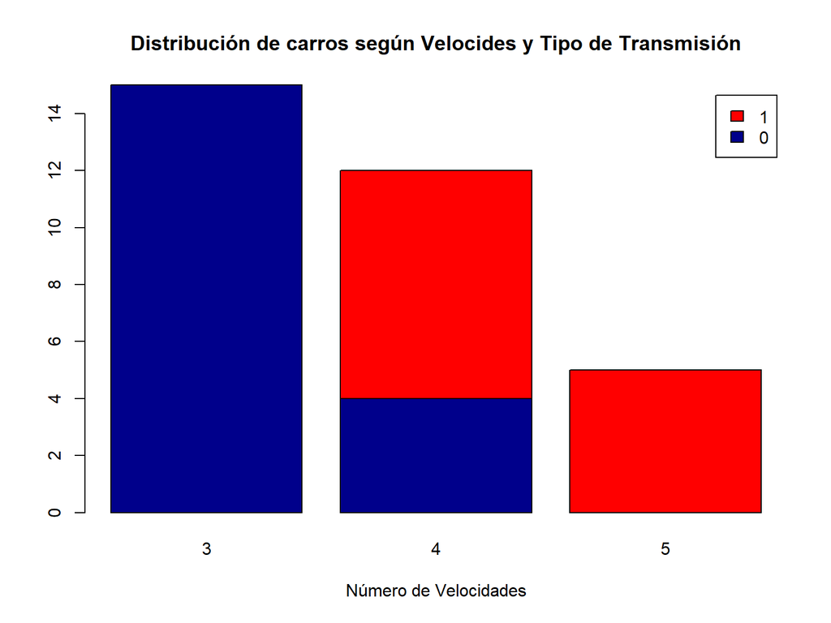

```r
counts <- table(mtcars$am, mtcars$gear)
barplot(counts, main="Distribución de carros según Velocides y Tipo de Transmisión",
  xlab="Número de Velocidades", col=c("darkblue","red"),
     legend = rownames(counts))
```

##Gráfico de Barras

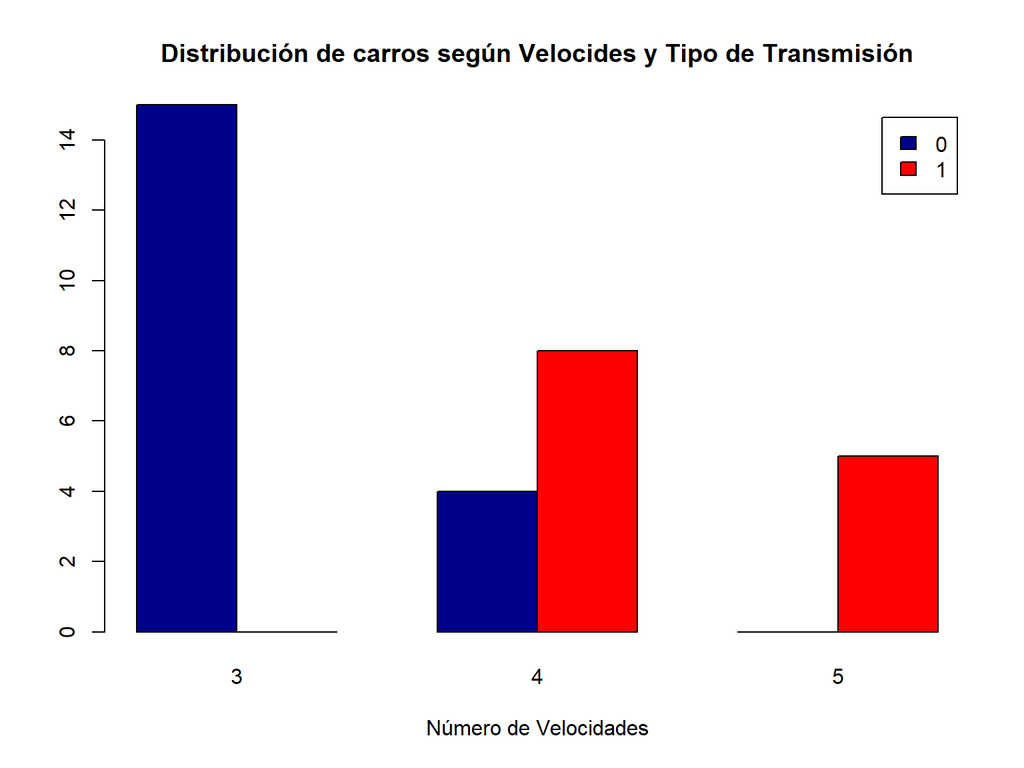

```r
counts <- table(mtcars$am, mtcars$gear)
barplot(counts, main="Distribución de carros según Velocides y Tipo de Transmisión",
  xlab="Número de Velocidades", col=c("darkblue","red"),
     legend = rownames(counts), beside=TRUE)
```

##Gráfico de lineas

Realice un gráfico de lineas de cada una de las respuesta a cada droga.

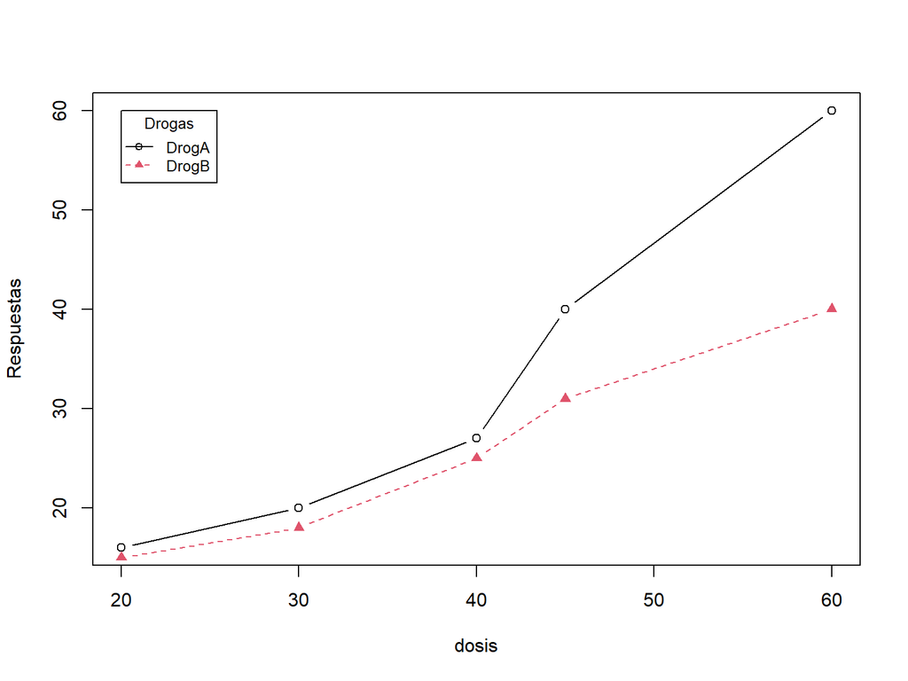

```r
dosis <- c(20, 30, 40, 45, 60)
drogA <- c(16, 20, 27, 40, 60)
drogB <- c(15, 18, 25, 31, 40)
plot(dosis, drogA, type="b", ylab="Respuestas",col=1)
lines(dosis,drogB, type="b",lty=2, pch=17,col=2)
legend(x=min(dosis), y=max(drogA,drogB), legend=c("DrogA","DrogB"), cex=0.8, col=c(1,2), pch=c(1,17), lty=c(1,2), title="Drogas")
```

##Diagrama Circular

% Realice un diagrama circular

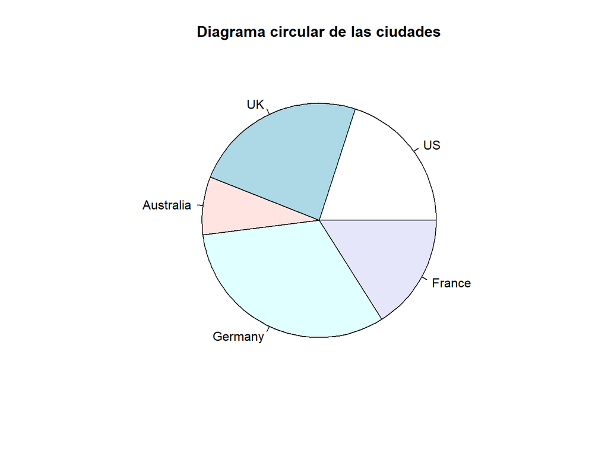

```r
frecuencia <- c(10, 12,4, 16, 8)
ciudades <- c("US", "UK", "Australia", "Germany", "France")
pie(frecuencia, labels = ciudades, main="Diagrama circular de las ciudades")
```

##Diagrama Boxplot

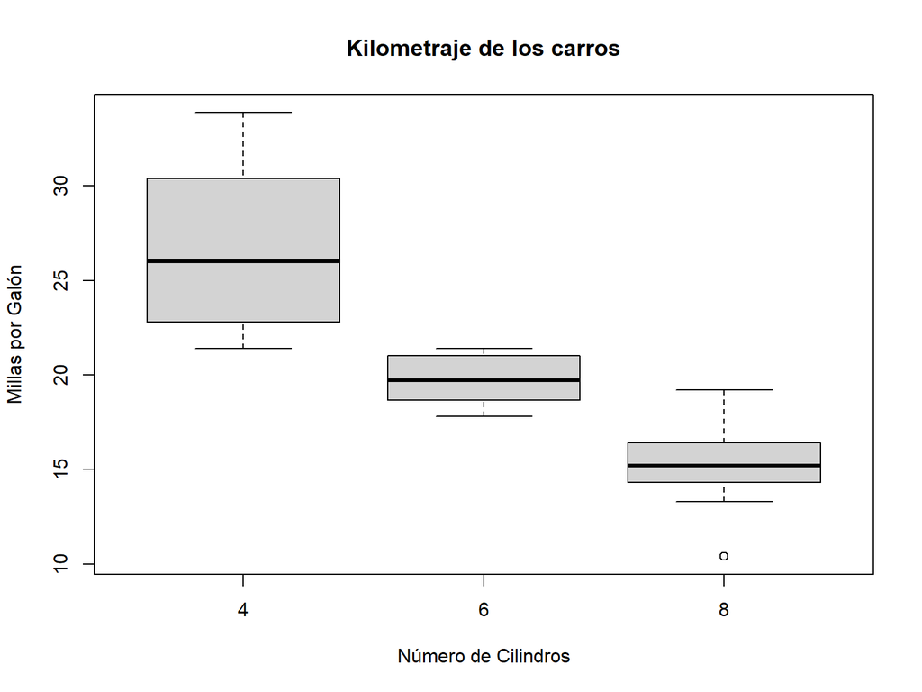

```r
boxplot(mpg~cyl,data=mtcars, main="Kilometraje de los carros",
     xlab="Número de Cilindros", ylab="Millas por Galón")
```

##Diagrama de Dispersión

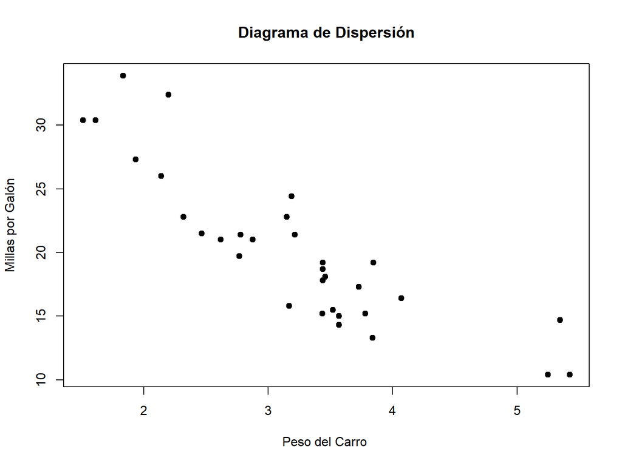

```r
plot(wt, mpg,main="Diagrama de Dispersión", xlab="Peso del Carro ", ylab="Millas por Galón", pch=19)
```

##Diagrama de Dispesión

```r
library(car)
```

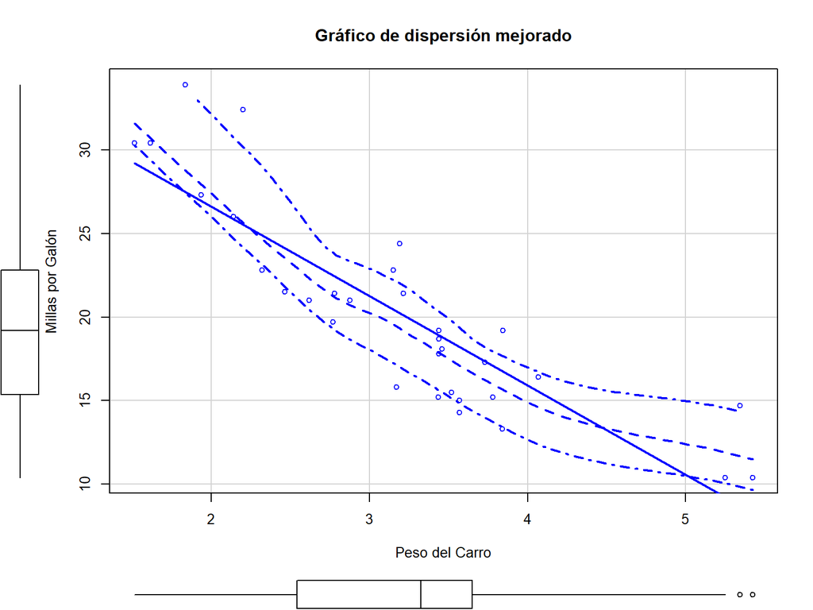

```r
scatterplot(mpg ~ wt, data=mtcars, xlab="Peso del Carro", ylab="Millas por Galón", main="Gráfico de dispersión mejorado")
```

##Matriz de Dispersión

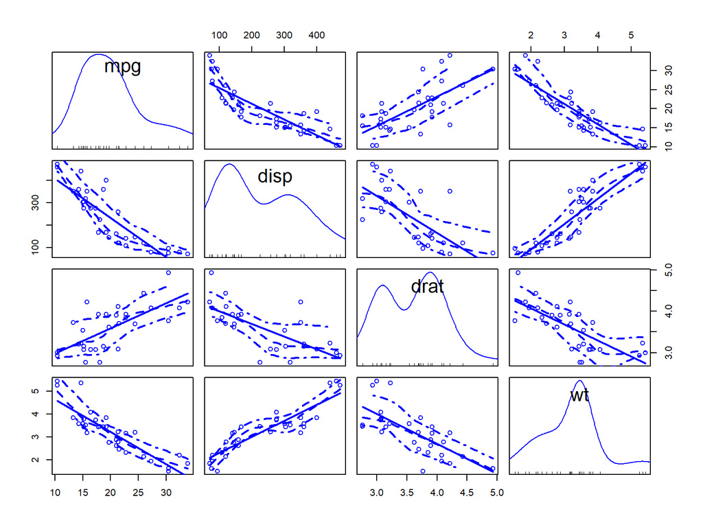

```r
library(car)
scatterplotMatrix(~mpg+disp+drat+wt, data=mtcars)
```

##Gráfico de Densidad

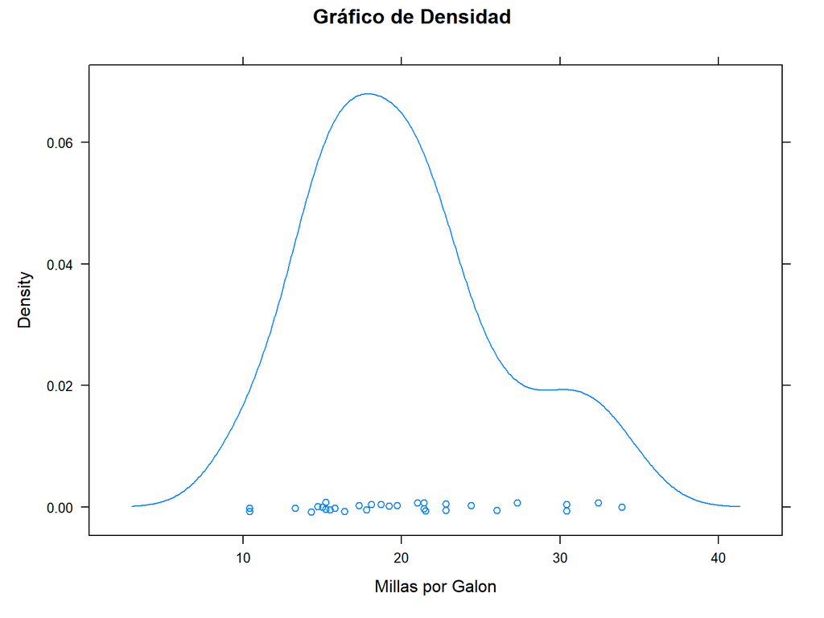

```r
library(lattice)

densityplot(~mpg, main="Gráfico de Densidad", xlab="Millas por Galon")
```

##Gráfico de Densidad

```r
attach(mtcars)
```

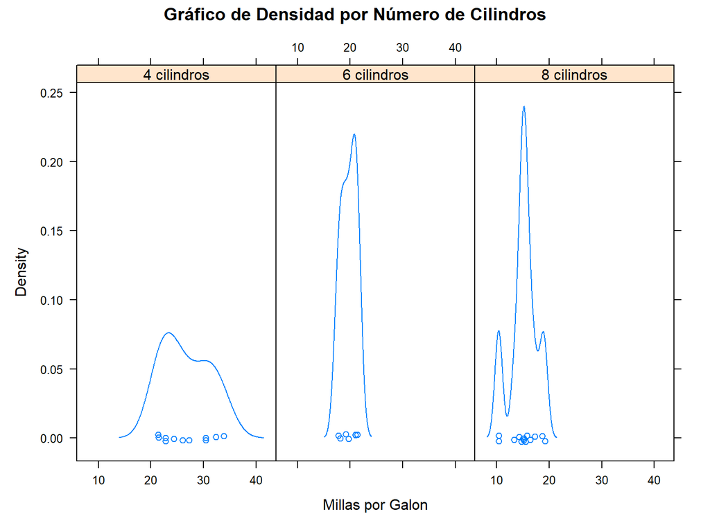

```r
cyl <- factor(cyl, levels=c(4, 6, 8), labels=c("4 cilindros", "6 cilindros", "8 cilindros"))
densityplot(~mpg | cyl,main="Gráfico de Densidad por Número de Cilindros",xlab="Millas por Galon")
```

##Para mayor información Para mayor información pueden investigar los siguientes links: Lattice: Multivariate Data Visualization with R http://lmdvr.r-forge.r-project.org/figures/figures.html

Trellis Graphics User’s Manual http://cm.bell-labs.com/cm/ms/departments/sia/doc/trellis.user.pdf

##ggplot2 Histograma

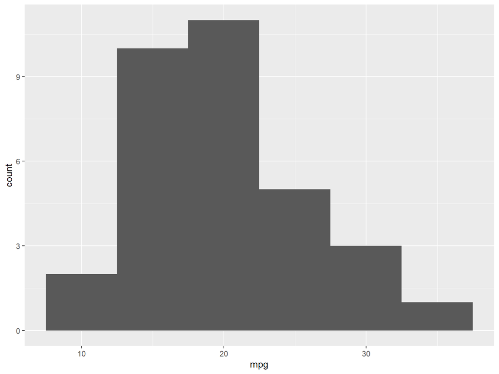

```r
library(ggplot2)
m <- ggplot(mtcars, aes(x = mpg))
m + geom_histogram(binwidth =5)
```

##Gráfico de Densidad

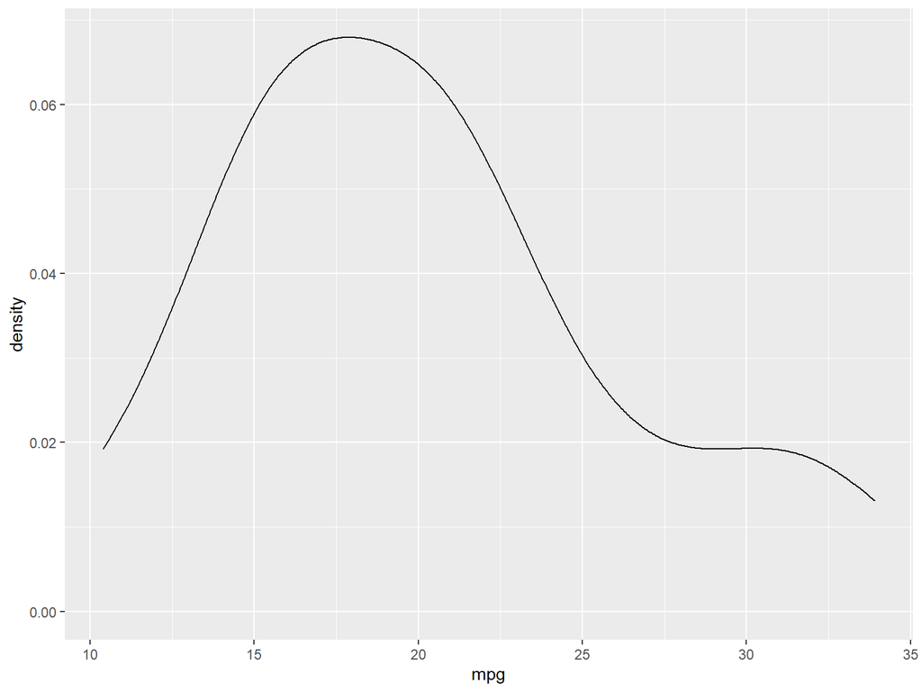

```r
m <- ggplot(mtcars, aes(x = mpg))
m + geom_density()
```

##Gráfico de Densidad

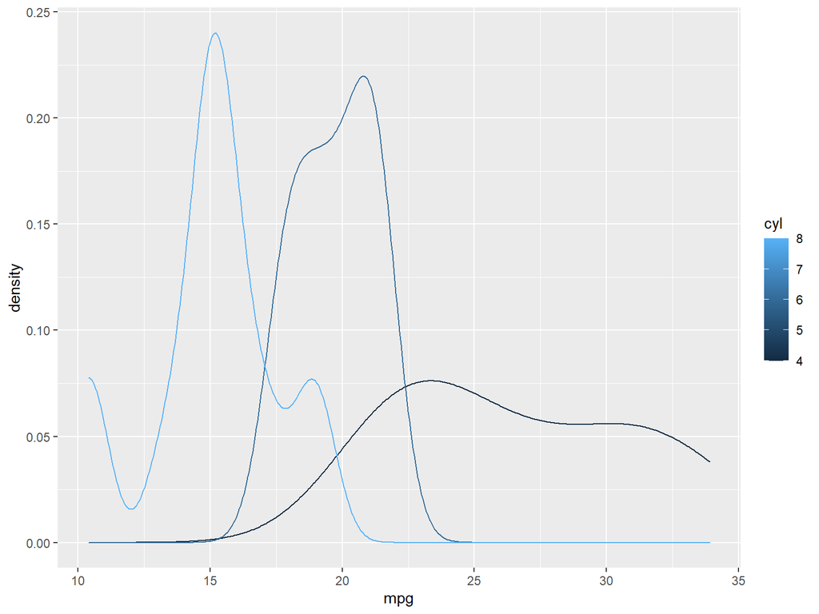

```r
m <- ggplot(mtcars, aes(x = mpg,colour=cyl,group=cyl))
m + geom_density()
```

##Diagrama de puntos

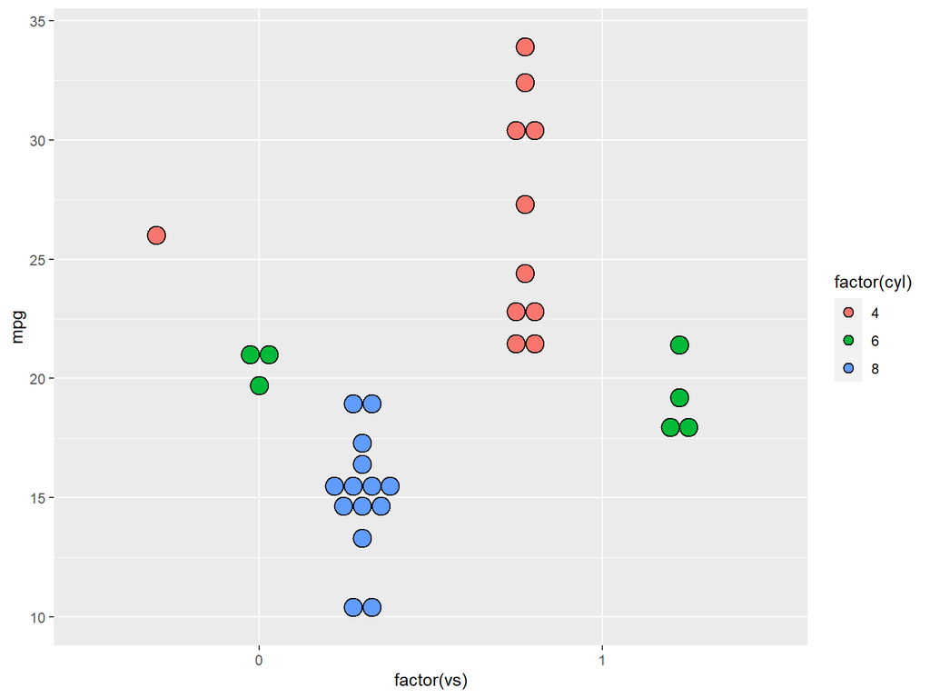

```r
m<-ggplot(mtcars, aes(x = factor(vs), fill = factor(cyl), y = mpg))
m + geom_dotplot(binaxis = "y", stackdir = "center", position = "dodge")
```

##Gráfico de Barras

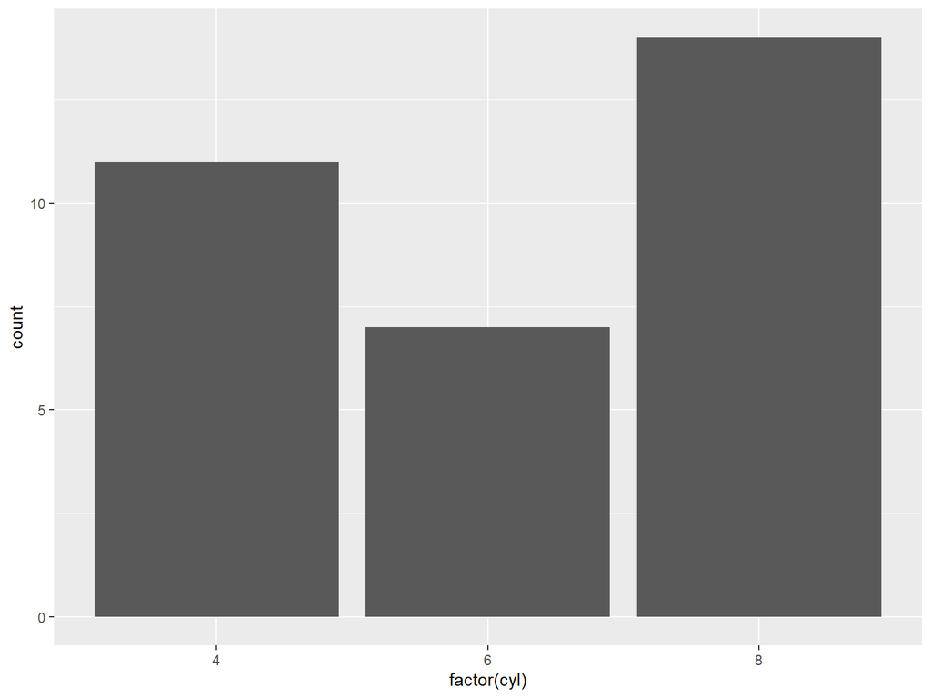

```r
r <- ggplot(mtcars, aes(factor(cyl)))
r + geom_bar()
```

##Gráfico de Barras

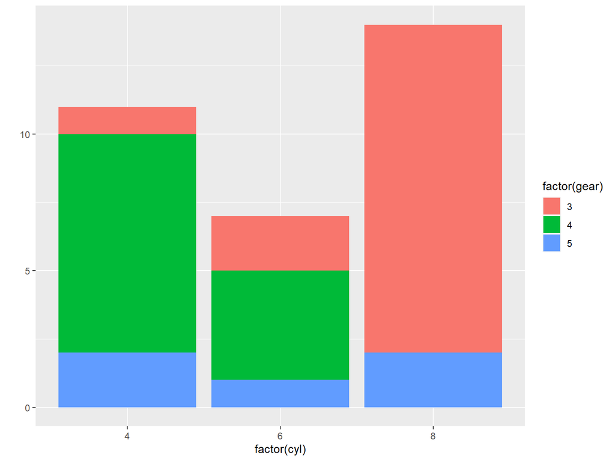

```r
qplot(factor(cyl), data=mtcars, geom="bar", fill=factor(gear))
```

##Diagrama Boxplot

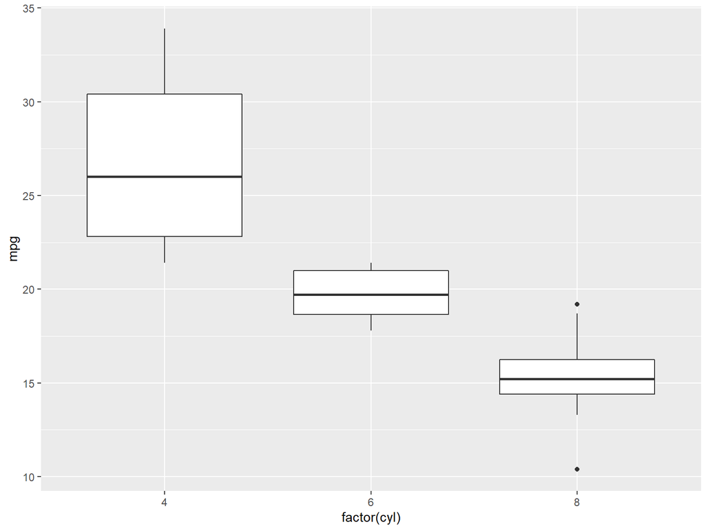

```r
m <- ggplot(mtcars, aes(factor(cyl),mpg))
m + geom_boxplot()
```

##Diagrama de Dispesión

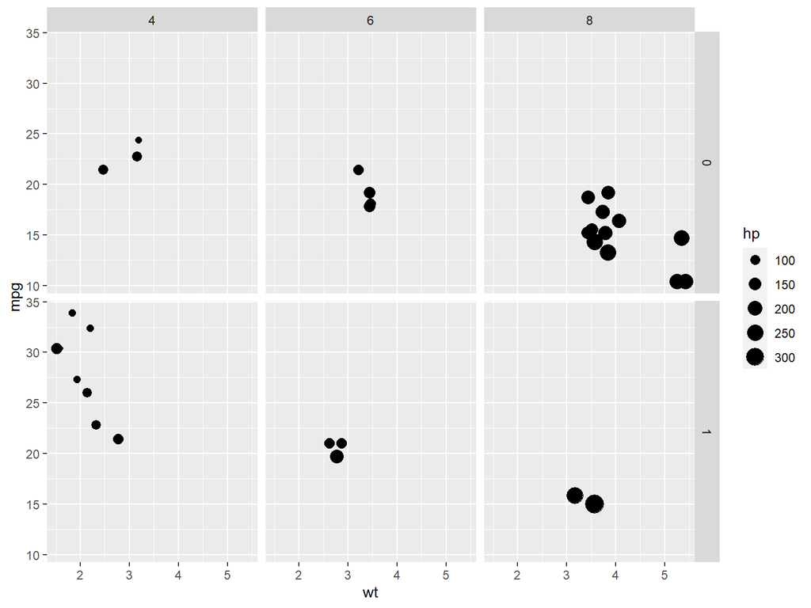

```r
qplot(wt,mpg, data=mtcars, facets=am~cyl, size=hp)
```

##Documentación Para mayor información pueden investigar en ggplot2 http://had.co.nz/ggplot2/